# Existe desigualdade de gênero em dados?

## Resumão no estilo TLDR (too long/muito longo, didn't read/não li):

- Foram feitas análises de comparação dos gêneros, ligando os resultados as **metáforas da desigualdade**;
- Os gráficos são construidos utilizando o pacote plotly, que são interativos.
- Homens são maioria na área;
- Sobre os salários, há predominância (propocional) de mulheres nos salários mais baixos e de homens nos mais altos;
- Homens tem cargos mais altos e mais tempo de experiência;
- Balanceando fatores como nível educacional, nível de senioridade, cargo e tempo de experiência, a diferença salarial deixa de ser identificável.
- Em primeiro olhar o resultado é positivo: ou seja, se tivermos as mesmas condições (tempo de experiência, cargos e formações mais requeridas), mulheres alcançar as maiores faixas salariais
- Então, para que a igualdade salarial seja atingida: é preciso entender porque mulheres não alcançam os mesmos espaços que homens e ser proativos em ações que mudem esse cenário.

## Falar de gênero parece que virou modinha, né? Vira e mexe tem alguém querendo falar sobre isso.

Mas porque esse tema é importante? O que ele muda na vida das pessoas? Do ponto de vista global, os principais desafios para um desenvolvimento sustentável foram definidos pela Organização das Nações Unidas. Entre os objetivos, existe um que chama a atenção para a questao de gênero (Objetivo 5).

[figure not shown]

A desigualdade não é de hoje, ela é consequência de séculos de opressão e desvalorização da mulher, padrão que foi perpetuado na nossa sociedade.

Do ponto de vista financeiro, o custo da desigualdade é alto. Calcula-se que a perda de capital humano pode chegar em até 160 trilhões de dólares à economia mundial. Essa perda acontece desde o acesso a educação formal para meninas até as mulheres que conseguem alcançar algum nível de escolaridade. Em geral, mulheres que conseguem se inserir no mercado de trabalho, sofrem com a inequidade salarial. Existem muitos casos onde mulheres e homens que fazem a mesma tarefa pelo mesmo tempo recebem salários diferentes.

Pensando nisso, esse estudo tem como objetivo avaliar as diferenças entre os gêneros na área de dados a partir do conjunto de dados da pesquisa "State of Data Brazil 2021".

[figure not shown]

Nos próximos passos vamos contando o que fizemos e as motivações das nossas análises

Inicialmente, são importados os pacotes e os dados

```python
#importando pacotes
import pandas as pd
import numpy as np
import matplotlib.pyplot as plt
import seaborn as sns
import plotly.express as px
import plotly.graph_objects as go
import plotly.graph_objects as go
from plotly.subplots import make_subplots
```

```python
#importando dados
df = pd.read_csv('/kaggle/input/state-of-data-2021/State of Data 2021 - Dataset - Pgina1.csv', low_memory=False)
```

Pra facilitar a leitura e compreensão dos resultados, foram feitas algumas edições necessárias no banco de dados.

- Exclusão de individuos que definiram o gênero como "Outro", que apesar de ser um grupo muito importante para a análise de gênero, ainda não traz uma população grande o suficiente para uma análise estatística adequada. Além disso, pode facilitar a identificação de indivíduos.
- Reordenação de algumas categorias
- Agrupamento e renomeação variáveis

Além disso, para facilitar a leitura do código, foi criada uma função para geração de um tipo de gráfico mais utilizado nesta análise.

```python
# Removendo linhas em que o gênero é igual a "outro"
df = df[df["('P1_b ', 'Genero')"] != "Outro"]

# Atualizando a variável  "('P2_g ', 'Nivel')" da seguinte forma
# Quando a pessoa respondeu que é gestor "('P2_d ', 'Gestor?')" e não respondeu a pergunta "('P2_g ', 'Nivel')",
# assume-se que o nível é "Gestor"

df.loc[(df["('P2_d ', 'Gestor?')"] == 1) & (df["('P2_g ', 'Nivel')"].isna()), "('P2_g ', 'Nivel')"] = 'Gestor'


# Atualizando a variável  "('P1_h ', 'Nivel de Ensino')"  da seguinte forma:
# Quando a pessoa  que ´refere não informar, define-se que a resposta foi None
df["('P1_h ', 'Nivel de Ensino')"] = df["('P1_h ', 'Nivel de Ensino')"].replace({'Prefiro não informar': None})

# Renomeando variáveis para que o nome fique mais curto e viável de inserir nos gráficos
df = df.rename(columns=({
"('P4_f_a ', 'MySQL')"                        : "MySQL",
"('P4_f_b ', 'Oracle')"                       : "Oracle",
"('P4_f_c ', 'SQL SERVER')"                   : "SQL SERVER",
"('P4_f_d ', 'SAP')"                          : "SAP",
"('P4_f_e ', 'Amazon Aurora ou RDS')"         : "Amazon Aurora ou RDS",
"('P4_f_f ', 'Amazon DynamoDB')"              : "Amazon DynamoDB",
"('P4_f_g ', 'CoachDB')"                      : "CoachDB",
"('P4_f_h ', 'Cassandra')"                    : "Cassandra",
"('P4_f_i ', 'MongoDB')"                      : "MongoDB",
"('P4_f_j ', 'MariaDB')"                      : "MariaDB",
"('P4_f_k ', 'Datomic')"                      : "Datomic",
"('P4_f_l ', 'S3')"                           : "S3",
"('P4_f_m ', 'PostgreSQL')"                   : "PostgreSQL",
"('P4_f_n ', 'ElasticSearch')"                : "ElasticSearch",
"('P4_f_o ', 'DB2')"                          : "DB2",
"('P4_f_p ', 'Microsoft Access')"             : "Microsoft Access",
"('P4_f_q ', 'SQLite')"                       : "SQLite",
"('P4_f_r ', 'Sybase')"                       : "Sybase",
"('P4_f_s ', 'Firebase')"                     : "Firebase",
"('P4_f_t ', 'Vertica')"                      : "Vertica",
"('P4_f_u ', 'Redis')"                        : "Redis",
"('P4_f_v ', 'Neo4J')"                        : "Neo4J",
"('P4_f_x ', 'Google BigQuery')"              : "Google BigQuery",
"('P4_f_y ', 'Google Firestore')"             : "Google Firestore",
"('P4_f_z ', 'Amazon Redshift')"              : "Amazon Redshift",
"('P4_f_z1 ', 'Amazon Athena')"               : "Amazon Athena",
"('P4_f_z2 ', 'Snowflake')"                   : "Snowflake",
"('P4_f_z3 ', 'Databricks')"                  : "Databricks",
"('P4_f_z4 ', 'HBase')"                       : "HBase",
"('P4_f_z5 ', 'Presto')"                      : "Presto",
"('P4_f_z6 ', 'Splunk')"                      : "Splunk",
"('P4_f_z7 ', 'SAP HANA')"                    : "SAP HANA",
"('P4_f_z8 ', 'Hive')"                        : "Hive",
"('P4_f_z9 ', 'Firebird')"                    : "Firebird"}))

#Renomeando categorias de variáveis para que o nome fique mais curto e viável de inserir nos gráficos

df["('P2_h ', 'Faixa salarial')"] = df["('P2_h ', 'Faixa salarial')"].replace({'Menos de R$ 1.000/mês' : "R&#36;1k",
                                             'de R$ 1.001/mês a R$ 2.000/mês'  : "R&#36;1k-2k",
                                             'de R$ 2.001/mês a R$ 3000/mês'   : "R&#36; 2k-3k",
                                             'de R$ 3.001/mês a R$ 4.000/mês'  : "R&#36; 3k-4k",
                                             'de R$ 4.001/mês a R$ 6.000/mês'  : "R&#36; 4k-6k",
                                             'de R$ 6.001/mês a R$ 8.000/mês'  : "R&#36; 6k-8k",
                                             'de R$ 8.001/mês a R$ 12.000/mês' : "R&#36; 8k-12k",
                                             'de R$ 12.001/mês a R$ 16.000/mês' : "R&#36; 12k-16k",
                                             'de R$ 16.001/mês a R$ 20.000/mês' : "R&#36; 16k-20k",
                                             'de R$ 20.001/mês a R$ 25.000/mês' : "R&#36; 20k-25k",
                                             'de R$ 25.001/mês a R$ 30.000/mês' : "R&#36; 25k-30k",
                                             'de R$ 30.001/mês a R$ 40.000/mês' : "R&#36; 30k-40k",
                                             'Acima de R$ 40.001/mês' : "R&#36; 40k"
                                                    })

df["('P2_i ', 'Quanto tempo de experiência na área de dados você tem?')"] = \
    df["('P2_i ', 'Quanto tempo de experiência na área de dados você tem?')"]\
    .replace({'Não tenho experiência na área de dados':'Não tenho experiência <br />na área de dados'})

df["('P2_j ', 'Quanto tempo de experiência na área de TI/Engenharia de Software você teve antes de começar a trabalhar na área de dados?')"] = \
            df["('P2_j ', 'Quanto tempo de experiência na área de TI/Engenharia de Software você teve antes de começar a trabalhar na área de dados?')"]. \
            replace({'Não tive experiência na área de TI/Engenharia de Software antes de começar a trabalhar na área de dados' :
                         'Não tive experiência<br /> em TI antes' })

df["('P2_f ', 'Cargo Atual')"] = df["('P2_f ', 'Cargo Atual')"].replace({
    "Cientista de Dados/Data Scientist"                       : "Cientista de Dados"
  , "Analista de BI/BI Analyst/Analytics Engineer"            : "Analista de BI"
  , "Analista de Dados/Data Analyst"                          : "Analista de Dados"
  , "Engenheiro de Dados/Data Engineer"                       : "Engenheiro de Dados"
  , "Outro"                                                   : "Outro"
  , "Analista de Negócios/Business Analyst"                   : "Analista de Negócios"
  , "Desenvolvedor ou Engenheiro de Software"                 : "Dev ou Engenheiro de Software"
  , "Engenheiro de Machine Learning/ML Engineer"              : "Engenheiro de Machine Learning"
  , "Outras Engenharias (não inclui dev)"                     : "Outras Engenharias (não inclui dev)"
  , "Estatístico"                                             : "Estatístico"
  , "Analista Administrativo"                                 : "Analista Administrativo"
  , "Analista de Inteligência de Mercado/Market Intelligence" : "Analista de Inteligência de Mercado"
  , "DBA/Administrador de Banco de Dados"                     : "Administrador de Banco de Dados"
  , "Analista de Sistemas/Analista de TI"                     : "Analista de Sistemas"
  , "Analista de Marketing"                                   : "Analista de Marketing"
  , "Técnico"                                                 : "Técnico"
  , "Suporte Técnico"                                         : "Suporte Técnico"
  , "Professor"                                               : "Professor"
  , "Arquiteto de Dados"                                      : "Arquiteto de Dados"
  , "Product Manager"                                         : "Product Manager"
  , "Arquiteto de dados"                                      : "Arquiteto de Dados" })
```

```python
df["('P3_a ', 'Qual o número aproximado de pessoas que atuam com dados na sua empresa hoje?')"] = df["('P3_a ', 'Qual o número aproximado de pessoas que atuam com dados na sua empresa hoje?')"].astype('category')
df["('P3_a ', 'Qual o número aproximado de pessoas que atuam com dados na sua empresa hoje?')"] =  \
  df["('P3_a ', 'Qual o número aproximado de pessoas que atuam com dados na sua empresa hoje?')"].cat.rename_categories(
                                                         {'Ainda não temos pessoas atuando com dados na empresa': '0' })


#Reordenando categorias de variáveis para deixar em uma ordem que faça mais sentido na apresentação gráfica
df["('P1_h ', 'Nivel de Ensino')"] = df["('P1_h ', 'Nivel de Ensino')"].astype('category')
df["('P1_h ', 'Nivel de Ensino')"] = df["('P1_h ', 'Nivel de Ensino')"].cat\
                                     .reorder_categories(['Não tenho graduação formal',
                                                          'Estudante de Graduação',
                                                          'Graduação/Bacharelado',
                                                          'Pós-graduação',
                                                          'Mestrado',
                                                          'Doutorado ou Phd'
                                                           ])
df["('P2_i ', 'Quanto tempo de experiência na área de dados você tem?')"] = \
    df["('P2_i ', 'Quanto tempo de experiência na área de dados você tem?')"].astype('category')

df["('P2_i ', 'Quanto tempo de experiência na área de dados você tem?')"] = \
    df["('P2_i ', 'Quanto tempo de experiência na área de dados você tem?')"].cat\
    .reorder_categories(['Não tenho experiência <br />na área de dados',
                           'Menos de 1 ano',
                           'de 1 a 2 anos',
                            'de 2 a 3 anos',
                           'de 4 a 5 anos',
                           'de 6 a 10 anos',
                           'Mais de 10 anos'])


df["('P2_c ', 'Numero de Funcionarios')"] = df["('P2_c ', 'Numero de Funcionarios')"].astype('category')
df["('P2_c ', 'Numero de Funcionarios')"] = df["('P2_c ', 'Numero de Funcionarios')"].cat\
                                            .reorder_categories(['de 1 a 5',
                                                                 'de 6 a 10',
                                                                 'de 11 a 50',
                                                                 'de 51 a 100',
                                                                 'de 101 a 500',
                                                                 'de 501 a 1000',
                                                                 'de 1001 a 3000',
                                                                 'Acima de 3000'])


df['faixa_salarial'] = df["('P2_h ', 'Faixa salarial')"].astype('category')
df['faixa_salarial'] = df['faixa_salarial'].cat.reorder_categories(["R&#36;1k",
                                                                    "R&#36;1k-2k", "R&#36; 2k-3k",
                                                                    "R&#36; 3k-4k", "R&#36; 4k-6k",
                                                                    "R&#36; 6k-8k", "R&#36; 8k-12k",
                                                                    "R&#36; 12k-16k", "R&#36; 16k-20k",
                                                                    "R&#36; 20k-25k", "R&#36; 25k-30k",
                                                                    "R&#36; 30k-40k", "R&#36; 40k" ])



df["('P2_j ', 'Quanto tempo de experiência na área de TI/Engenharia de Software você teve antes de começar a trabalhar na área de dados?')"] = \
        df["('P2_j ', 'Quanto tempo de experiência na área de TI/Engenharia de Software você teve antes de começar a trabalhar na área de dados?')"].astype('category')

df["('P2_j ', 'Quanto tempo de experiência na área de TI/Engenharia de Software você teve antes de começar a trabalhar na área de dados?')"] = \
  df["('P2_j ', 'Quanto tempo de experiência na área de TI/Engenharia de Software você teve antes de começar a trabalhar na área de dados?')"]. \
  cat.reorder_categories(['Não tive experiência<br /> em TI antes',
                          'Menos de 1 ano',
                          'de 1 a 2 anos',
                          'de 2 a 3 anos',
                          'de 4 a 5 anos',
                          'de 6 a 10 anos',
                          'Mais de 10 anos'])


df["('P2_g ', 'Nivel')"] = df["('P2_g ', 'Nivel')"].astype('category')
df["('P2_g ', 'Nivel')"] = df["('P2_g ', 'Nivel')"].cat\
                          .reorder_categories(['Júnior', 'Pleno', 'Sênior', 'Gestor'])

df["('P3_a ', 'Qual o número aproximado de pessoas que atuam com dados na sua empresa hoje?')"] =\
    df["('P3_a ', 'Qual o número aproximado de pessoas que atuam com dados na sua empresa hoje?')"].astype('category')

df["('P3_a ', 'Qual o número aproximado de pessoas que atuam com dados na sua empresa hoje?')"] = \
    df["('P3_a ', 'Qual o número aproximado de pessoas que atuam com dados na sua empresa hoje?')"].cat.reorder_categories([
                                                         '0',
                                                         '1 - 3',
                                                         '4 - 10',
                                                         '11 - 20',
                                                         '21 - 50',
                                                         '51 - 100',
                                                         '101 - 300',
                                                         'Acima de 300 pessoas'
                                                            ])


# criando variavel "desfecho" para ser utilizada nos gráficos a seguir
desfecho = "('P1_b ', 'Genero')"
```

```python
#Função que cria gráficos de linha acoplado a gráfico de barra que mostra a diferença entre os grupos

def faz_grafico_diferenca_propocao(df, variavel, desfecho, titulo):
    fig = make_subplots(rows=2, cols=1, row_heights = [3,5],
                        specs=[[{"secondary_y":True}],[{"secondary_y":True}]],
                        print_grid=False,
                        shared_xaxes="rows" )

    prop_genero = pd.crosstab(df[variavel], df[desfecho], normalize='columns')*100
    novo_df = pd.DataFrame(prop_genero['Feminino'] - prop_genero['Masculino'], columns=['diff'])
    linhas_2 = px.bar(novo_df, x=novo_df.index, y='diff', color_discrete_sequence = ['#710c04','lightgray'])

    linhas_2.update_layout(xaxis_showticklabels=False)
    for d in linhas_2.data:
        fig.add_trace((go.Bar(x=d['x'], y=d['y'], name = "Diferença <br />(Feminino - Masculino)", marker_color=np.where(novo_df["diff"]>0, '#710c04','lightgray'))), row=1, col=1)

    prop_genero = pd.crosstab(df[variavel],df[desfecho],normalize='columns')*100
    linhas_1 = px.line(prop_genero, x=prop_genero.index, y=['Feminino','Masculino'], markers=True,
                  color_discrete_sequence = ['#710c04','lightgray' ])

    for d in linhas_1.data:
        fig.add_trace((go.Scatter(x=d['x'], y=d['y'], name = d['name'], line=d['line'], yaxis=d['yaxis'])), row=2, col=1)


    fig.update_layout(plot_bgcolor='rgba(0,0,0,0)')
    fig.update_layout(xaxis_showticklabels=False)

    fig['layout']['title']= titulo
    fig['layout']['yaxis']['title']='Diferença entre<br /> proporções (%)'
    fig['layout']['yaxis3']['title']='Proporção (%)'
    fig.show()
```

# Diferenças salariais

Para avaliar as diferenças salariais, é apresentada, inicialmente, uma visualização no estilo de pirâmide etária, utilizando as faixas salariais.

Com essa visualização é possivel enxergar a variação de pessoas em cada faixa de salário e como cada gênero é representado quantitativamente.

Fica bem claro que a presença absoluta feminina em todas as faixas é consideravelmente menor, mas ela quase desaparece nas 3 faixas mais altas. Assim, além de exemplificar a diferença salarial, a pirâmide também deixa claro a baixa representatividade de mulheres no mundo de dados. Nessa pesquisa, o total de respondentes mulheres foi de 493, o que representa 18,7% dos respondentes (como pode ser visto na tabela abaixo do gráfico de pirâmide).

```python
#@title

#criando gráfico de pirâmide para salários

abs_genero = pd.crosstab(df["faixa_salarial"],df["('P1_b ', 'Genero')"])

women_pop = list(abs_genero.Feminino)
men_pop   = list(abs_genero.Masculino)
men_pop = [element * -1 for element in men_pop]

faixa = list(abs_genero.index.values)

fig = go.Figure()
fig.add_trace(go.Bar(
    y=faixa,
    x=men_pop,
    name='Masculino',
    marker_color='lightgray',
    orientation='h'
))
fig.add_trace(go.Bar(
    y=faixa,
    x=women_pop,
    name='Feminino',
    marker_color='#710c04',
    orientation='h'
))

fig['layout']['title']= "Pirâmide salarial segundo o gênero"
fig['layout']['yaxis']['title']='Faixa salarial'

fig.update_layout(barmode='relative', xaxis_tickangle=-90)
fig.update_layout(plot_bgcolor='rgba(0,0,0,0)')
fig.update_layout( width=800, height=500)
fig.show()
```

[interactive chart not shown]

```python
#@title

#contruindo tabelas de frequências absolutas e percentuais
# a partir da concatenação de duas crosstabs (frequencia absoluta e percentual)

tab = pd.concat(
[pd.crosstab(index=df["('P1_b ', 'Genero')"], columns = 'count').transpose(),
pd.crosstab(index=df["('P1_b ', 'Genero')"], columns = 'count',normalize=True).transpose()*100]).T

# mudando o nome das colunas
tab.set_axis(['Freq',"%"],axis=1,inplace=True)

tab.index.name = 'Gênero'

tab
```

| Gênero | Freq | % |
| --- | --- | --- |
| Feminino | 493.0 | 18.695487 |
| Masculino | 2144.0 | 81.304513 |

A diferença salarial fica ainda mais clara quando ignoramos os números absolutos e vemos as proporções dentro dos grupos (gêneros).

Para essa observação, são apresentados dois gráficos. Embaixo, um gráfico de linhas que apresentas as proporções salariais dentro de cada genêro e, acima dele, um gráfico de barras que mostra a diferença entre essas propoções. Quando a diferença é positiva, indica que as mulheres tem uma maior proporção do que homens naquela faixa salarial.

Nesse caso, vemos que a curva de salário segue o esperado: valores muito baixos e muito altos são pouco frequentes, e a maioria das pessoas recebem valores intermediários.

Um ponto de atenção nesse gráfico é que que a maior diferença entre os gêneros ocorre na faixa de 12 a 16 mil reais por mês, onde há uma diferença de 4% (7,8% das mulheres está nessa faixa, contra 11,9% dos homens). Um ponto interessante é que, juridicamente se define a faixa salarial acima de 12.867,14 como ["Trabalhadores Hipersuficientes"](https://www.conjur.com.br/2021-dez-25/trt-empregado-nao-diploma-hipersuficiente) e é exatamente nessa faixa que os homens passam a superar as mulheres

```python
faz_grafico_diferenca_propocao(df, 'faixa_salarial', desfecho,
                               'Comparação entre as proproções de faixas salariais dentro <br /> de cada gênero')
```

[interactive chart not shown]

Esse resultado nos leva a seguinte pergunta:

**Existem diferenças objetivas entre homens e mulheres que justifiquem a disparidade salarial? Ou seja, é possível encontrar fatores como formação, tempo de experiência, entre outros, que auxiliem a explicar a disparidade?**

# O efeito tesoura: Homens tem cargos em maior nível

Ao longo da análise, conforme as diferenças de gênero são investigadas, podemos encontrar semelhanças entre o mundo de dados e outros ambientes em que as desigualadades de gênero são velhas conhecidas. Algumas dessas desigualdades são tão conhecidas que tem nomes, são as metáforas da desigualdade. Deste modo, apontaremos quando os dados desse estudo refletirem tais metáforas

Uma dessas metáforas é o **"efeito tesoura"**. Esse nome se deve ao desenho do gráfico que apresenta o número ou propoção de pessoas por gênero conforme a carreira avança.

Quando observamos a proporção de cargos dentro de cada gêneros, conseguimos ver com clareza o efeito tesoura para o nível de senioridade por gênero: a proporção entre mulheres decai conforme o nível do cargo aumenta e o inverso acontece para homens.

```python
faz_grafico_diferenca_propocao(df, "('P2_g ', 'Nivel')", desfecho,
                        'Comparação das proproções dos níveis de senioridade <br /> dentro de cada gênero')
```

[interactive chart not shown]

# Homens tem maior nível de escolaridade ou tempo de experiência?

**Nível de escolaridade**

Quando se analisa o nível de escolaridade, vemos que a proporção entre os homens é levemente maior nos níveis de escolaridade mais baixa. A curva das mulheres passa a ser superior a dos homens nos níveis de escolaridade mais alta.

Aqui podemos tratar de outra metáfora da desigualdade: **"o chão grudento"**. Essa metáfora fala da dificuldade das mulheres deslancharem nas suas carreiras por situações que as "grudam". Nesse caso, apesar de terem tempo de estudo igual ou superior aos homens, algo tem atrasado as mulheres de alcançar os salários mais altos.

```python
faz_grafico_diferenca_propocao(df, "('P1_h ', 'Nivel de Ensino')", desfecho,
                        'Comparação das proproções dos níveis de escolaridade <br /> dentro de cada gênero')
```

[interactive chart not shown]

**Área de formação**

No gráfico abaixo são apresentadas as proporções de cada área de formação dentro dos gêneros. Observa-se por exemplo, uma grande diferença entre as proporções de homens e mulheres que fazem cursos relacionados à computação\engenharia de software\S.I.\T.I (44% dos homens vs 35 % das mulheres). Comportamento diferente acontece nas áreas de Estatística/Matematica e Marketing onde a proporção de mulheres supera a masculina.

```python
# Criando gráficos de barras horizontais

#criando tabela cruzada para ser criada como input do gráfico de barras
prop_form = pd.crosstab(df["('P1_i ', 'Área de Formação')"],df["('P1_b ', 'Genero')"],normalize='columns')\
            .sort_values(by='Feminino',ascending=True)*100

formacao = list(prop_form.index.values)

fig = go.Figure()
fig.add_trace(go.Bar(
    y=formacao,
    x=prop_form['Masculino'] ,
    name='Masculino',
    marker_color='lightgray',
    orientation='h'
))
fig.add_trace(go.Bar(
    y=formacao,
    x=prop_form['Feminino'] ,
    name='Feminino',
    marker_color='#710c04',
    orientation='h'
))

fig.update_layout(title="Proporção cada categoria de formação entre homens e mulheres")
fig.update_layout(barmode='group', xaxis_tickangle=-45)
fig.update_layout( width=900, height=500)
fig.update_layout(plot_bgcolor='rgba(0,0,0,0)')
fig.show()
```

[interactive chart not shown]

De maneira complementar, no gráfico abaixo podemos observar também os percentuais de gênero dentro de cada área. Nesse caso, as áreas com maior prevalência feminina ficam ainda mais claras. Sendo que algumas áreas superam a proporção geral de mulheres (acima da linha preta), são elas: estatística, marketing e cinecias biológicas e relacionadas.

```python
# criando tabela  com as frequencias percentuais em cada genero
# para poder obter o percentual feminina amostra e utilizá-lo como referencial no gráfico
tab_genero = pd.crosstab(df["('P1_b ', 'Genero')"],columns='count',normalize='columns')*100

media_participacap_feminina =  tab_genero.loc['Feminino']['count']


#criando tabela cruzada formação vs genero para ser criada como input do gráfico de barras
prop_form = pd.crosstab(df["('P1_i ', 'Área de Formação')"],df["('P1_b ', 'Genero')"],normalize='index')\
            .sort_values(by='Feminino',ascending=False)*100

formacao = list(prop_form.index.values)



fig = go.Figure()
fig.add_trace(go.Bar(
    y=formacao,
    orientation='h',
    x=prop_form['Feminino'] ,
    name='Feminino',
    marker_color='#710c04',
))
fig.add_trace(go.Bar(
    y=formacao,
    x=prop_form['Masculino'] ,
    name='Masculino',
    marker_color='lightgray',
    orientation='h'
))

fig.update_layout(title="Proporção de homens e mulheres dentro de cada categoria de formação")
fig.update_layout(barmode='stack', xaxis_tickangle=-45)
fig.update_layout( width=1000, height=400)
fig.update_layout(plot_bgcolor='rgba(0,0,0,0)')
fig.add_vline(x=media_participacap_feminina,y1=0.85,line_color="black")
fig.add_annotation(x=media_participacap_feminina, y=8,
            text="Proporção geral de mulheres",showarrow=True,yshift=10,arrowhead=1)
fig.show()
```

[interactive chart not shown]

**Tempo de experiência**

Quando falamos em tempo de experiência em dados, entre as mulheres existe uma proporção maior das que tem menos tempo de experiência.

Podemos fazer uma analogia aqui mais uma metáfora da desiguadade conhecida como "cano furado". Essa metáfora fala da perda de pessoas ao longo dos anos, principalmente quando se relaciona a mulheres. Podemos fazer a seguinte reflexão: mulheres tem menor tempo de experiência pois passaram a ingressar mais recentemente ou por que não conseguem permanecer muito tempo e geram a situação definida na metáfora do cano furado?

Para responder essa pergunta, é importante que esses dados continuem a ser coletados periodicamente para que possamos avaliar se esse esse padrão se perpetua, ou se estamos conseguindo tapar esse buraco e manter mulheres experientes dentro da área.

```python
faz_grafico_diferenca_propocao(df, "('P2_i ', 'Quanto tempo de experiência na área de dados você tem?')", desfecho,
                        'Comparação das proproções dos tempos de experiência em dados<br /> dentro de cada gênero')
```

[interactive chart not shown]

Em relação a experiência previa em TI/Engenharia de software, os grupos são mais semelhantes. Mesmo assim, há um destaque para maior proporção de mulheres sem experiência nesse quesito.

É possível levantar a hipótese que mulheres tenham sido mais atraídas para a área de dados antes de tentar algo em computação pura.

```python
faz_grafico_diferenca_propocao(df, "('P2_j ', 'Quanto tempo de experiência na área de TI/Engenharia de Software você teve antes de começar a trabalhar na área de dados?')",
                               desfecho,
                               'Comparação das proproções do tempo de experiência prévia <br /> em TI dentro de cada gênero')
```

[interactive chart not shown]

# Quais são os cargos com maior representatividade feminina?

Um outro fator que pode influenciar na valorização do profissional é o cargo que ocupa. Por diversos motivos, as faixas salariais de alguns cargos são superiores a de outros. O gráfico abaixo mostra o percentual de homens e mulheres dentro de cada possível cargo. Vemos que as mulheres, em geral, superam o percentual geral da amostra (linha preta) em cargos de analista, já os homens são maioria em cargos relacionados à engenharia.

```python
#criando gráfico de barras empilhadas para cargos

prop_form = pd.crosstab(df["('P2_f ', 'Cargo Atual')"],df["('P1_b ', 'Genero')"],normalize='index')\
            .sort_values(by='Feminino',ascending=False)*100

cargo = list(prop_form.index.values)



fig = go.Figure()
fig.add_trace(go.Bar(
    y=cargo,
    orientation='h',
    x=prop_form['Feminino'] ,
    name='Feminino',
    marker_color='#710c04',
))
fig.add_trace(go.Bar(
    y=cargo,
    x=prop_form['Masculino'] ,
    name='Masculino',
    marker_color='lightgray',
    orientation='h'
))

# Here we modify the tickangle of the xaxis, resulting in rotated labels.
fig.update_layout(title="Proporção de gênero dentro de cada ocupação")
fig.update_layout(barmode='stack', xaxis_tickangle=-45)
fig.update_layout(plot_bgcolor='rgba(0,0,0,0)')
fig.add_vline(x=media_participacap_feminina,y1=.85,line_color="black")
fig.add_annotation(x=media_participacap_feminina, y=8,
            text="Proporção geral de mulheres",showarrow=True,yshift=180,arrowhead=1)
fig.show()
```

[interactive chart not shown]

# Porte das empresas em que trabalham

Um outro fator que pode interferir no salário é o porte das empresas em que esses funcionários trabalham. Pensando nisso, os gráficos abaixo comparam a quantidade de funcionários das empresas de homens e mulheres. Quando falamos em número de funcinários na empresa de forma geral, não é possível identificar uma diferença entre os gêneros. Quando falamos na quantidade de funcionários em dados, podemos destacar que existe uma proporção maior de homens trabalhando em empresa com 4 a 10 funcionários.

```python
fig = make_subplots(rows=1, cols=2)

var = "('P2_c ', 'Numero de Funcionarios')"


prop_genero = pd.crosstab(df[var],df["('P1_b ', 'Genero')"],normalize='columns')*100
g1 = px.line(prop_genero, x=prop_genero.index, y=['Feminino','Masculino'], markers=True,
              color_discrete_sequence = ['#710c04','lightgray' ]
               )
for d in g1.data:
        fig.add_trace((go.Scatter(x=d['x'], y=d['y'], name = d['name'], line=d['line'], yaxis=d['yaxis'],showlegend=False)), row=1, col=1)


var = "('P3_a ', 'Qual o número aproximado de pessoas que atuam com dados na sua empresa hoje?')"


prop_genero = pd.crosstab(df[var],df["('P1_b ', 'Genero')"],normalize='columns')*100
g2 = px.line(prop_genero, x=prop_genero.index, y=['Feminino','Masculino'], markers=True,
              color_discrete_sequence = ['#710c04','lightgray' ]
               )

for d in g2.data:
        fig.add_trace((go.Scatter(x=d['x'], y=d['y'], name = d['name'], line=d['line'], yaxis=d['yaxis'])), row=1, col=2)




fig['layout']['title'] = "Proporção do número de funcionários geral (esquerda) e em dados(direita) em cada gênero"
fig['layout']['yaxis']['title']='Proporção(%)'
fig['layout']['yaxis2']['title']='Proporção(%)'
fig['layout']['xaxis']['title']='Número de funcionários em geral'
fig['layout']['xaxis2']['title']='Número de funcionários em dados'
fig.update_layout(plot_bgcolor='rgba(0,0,0,0)')
fig['layout']['yaxis2']['range']=[0,35]
fig['layout']['yaxis']['range']=[0,35]
#fig.update_layout()

fig.show()
```

[interactive chart not shown]

# Ferramentas e linguagens mais utilizadas

Neste ponto são analisadas as linguagens de programação mais citadas entre homens e mulheres, que também são um fator de possível influência no salário. Observa-se que a proporção de homens que cita Python é superior a de mulheres (41% de homens contra 32% das mulheres). Em contrapartida, as mulheres tem maior proporção das que citam SQL ou que não utilizam linguagem.

```python
lista_P4_e = ["('P1_b ', 'Genero')","('P4_e_c ', 'Python')",
"('P4_e_f ', 'Java')","('P4_e_m ', 'Javascript')",
#"('P4_e_g ', 'Julia')",
"('P4_e_j ', 'Scala')","('P4_e_d ', 'C/C++/C#')",
"('P4_e_e ', '.NET')","('P4_e_k ', 'Matlab')",
"('P4_e_l ', 'PHP')","('P4_e_b ', 'R ')",
"('P4_e_h ', 'SAS/Stata')","('P4_e_i ', 'Visual Basic/VBA')",
"('P4_e_n ', 'Não utilizo nenhuma linguagem')","('P4_e_a ', 'SQL')"]


tab = df[lista_P4_e].groupby("('P1_b ', 'Genero')").mean()

tab = tab.transpose()

linguagem =  ['Python', 'Java',
 'Javascript', 'Scala', 'C/C++/C#', '.NET', 'Matlab', 'PHP', 'R ',
 'SAS/Stata', 'Visual Basic/VBA', 'Não utilizo nenhuma linguagem','SQL']


fig = go.Figure()
fig.add_trace(go.Bar(
    x=linguagem,
    y=tab['Masculino'] ,
    name='Masculino',
    marker_color='lightgray',
    orientation='v'
))
fig.add_trace(go.Bar(
    x=linguagem,
    y=tab['Feminino'] ,
    name='Feminino',
    marker_color='#710c04',#'#bd1e1e',
    orientation='v'
))

# Here we modify the tickangle of the xaxis, resulting in rotated labels.
fig.update_layout(barmode='group', xaxis_tickangle=-45)
#fig.add_hrect(y0=6.5, y1=8.5, line_width=0, fillcolor="gray", opacity=0.2)
fig.update_layout(plot_bgcolor='rgba(0,0,0,0)')
fig.add_vrect(x0=-.5, x1=0.5,line_dash="dash", line_color="gray",line_width=1,
              annotation_text="Predominância masculina",
              annotation_position="top left",
              annotation=dict(font_size=12))
fig.add_vrect(x0=8.5, x1=12.5,line_dash="dash", line_color="gray",line_width=1,
              annotation_text="Predominância feminina",
              annotation_position="top left",
              annotation=dict(font_size=12))

fig.update_layout(title="Proporções das linguagens dentro de cada gênero")

fig.show()
```

[interactive chart not shown]

# Maiores interesses

Outra caractrística no mercado de trabalho que pode ser influenciada pelo gênero, são os itens mais buscados pelas pessoas. Historicamente, homens sabem negociar melhor seus salários e tem menos aversão a risco, o que facilita a troca de emprego considerando apenas a remuneração. Os dados da pesquisa confirmaram essa hipótese, visto que quando perguntados sobre os interessem mais homens citam remuneração e benefícios do que mulheres.

Por outro lado, as mulheres apresentam maior frequência do que homens no interesse por ambiente, propósito e qualidade dos gestores, além da flexibilidade do trabalho remoto. Tais pontos podem refletir a necessidade de mulheres estarem em ambientes seguros (o que infelizmente ainda pode ser um desafio). Além disso, a flexibilidade de trabalho também é um fator importante, visto que mulheres são responsáveis pelas tarefas domesticas e familiares, sem ter com quem dividir.

```python
lista_P2_o = ["('P1_b ', 'Genero')","('P2_o_a ', 'Remuneração/Salário')", "('P2_o_b ', 'Benefícios')",
       "('P2_o_f ', 'Oportunidade de aprendizado e trabalhar com referências na área')",
       "('P2_o_j ', 'Reputação que a empresa tem no mercado')",
       "('P2_o_h ', 'Maturidade da empresa em termos de tecnologia e dados')",
       "('P2_o_g ', 'Plano de carreira e oportunidades de crescimento profissional')",
       "('P2_o_i ', 'Qualidade dos gestores e líderes')",
       "('P2_o_d ', 'Flexibilidade de trabalho remoto')",
       "('P2_o_c ', 'Propósito do trabalho e da empresa')",
       "('P2_o_e ', 'Ambiente e clima de trabalho')"]


tab = df[lista_P2_o].groupby("('P1_b ', 'Genero')").mean()

tab = tab.transpose()

tab

motivacoes = ['Remuneração','Benefícios','Oportunidades','Reputação',\
              'Maturidade tech','Plano de carreira', 'Qualidade gestores','Flexibilidade remoto',\
             'Propósito', 'Ambiente']


fig = go.Figure()
fig.add_trace(go.Bar(
    x=motivacoes,
    y=tab['Masculino'] ,
    name='Masculino',
    marker_color='lightgray',
    orientation='v'
))
fig.add_trace(go.Bar(
    x=motivacoes,
    y=tab['Feminino'] ,
    name='Feminino',
    marker_color='#710c04',
    orientation='v'
))

# Here we modify the tickangle of the xaxis, resulting in rotated labels.
fig.update_layout(barmode='group', xaxis_tickangle=-45)
#fig.add_hrect(y0=6.5, y1=8.5, line_width=0, fillcolor="gray", opacity=0.2)
fig.update_layout(plot_bgcolor='rgba(0,0,0,0)')
fig.add_vrect(x0=-.5, x1=2.5,line_dash="dash", line_color="gray",line_width=1,
              annotation_text="Predominância masculina",
              annotation_position="top right",
              annotation=dict(font_size=18))
fig.add_vrect(x0=5.5, x1=9.5,line_dash="dash", line_color="gray",line_width=1,
              annotation_text="Predominância feminina",
              annotation_position="top left",
              annotation=dict(font_size=18))

fig.update_layout(title="Proporções dos maiores interesses em cada gênero")

fig.show()
```

[interactive chart not shown]

# Pontos principais da análise exploratória

Em resumo, a análise exploratória realizada mostra que ainda que mulheres tenham, proporcionalmente, maiores níveis educacionais do que os homens, existe uma disparidade salarial e dos níveis de cargos ocupados por homens e mulheres. É possível que essa disparidade seja explicada, por exemplo, pelo maior tempo de experiência ou formação em carreiras ligadas à computação entre os homens, entre outros.

Sabemos que variáveis confundidoras como formação, tempo de experiência, nível educacional, cargo podem afetar diretamente os níveis salariais e cargos ocupados. Por isso, as diferenças entre homens e mulheres nessas variáveis dificultam o entendimento de quais são os causadores da disparidade salarial. Na prática, gostaríamos de entender:

- Se os grupos fossem semelhantes em relação à variáveis confundidoras, a disparidade salarial deixaria de existir?
- O padrão de definição de salários para homens é o mesmo seguido para mulheres?

Para entender melhor essas perguntas, construí uma árvore de decisão em que a variável resposta era o salário (categorizado em três níveis) e a base de treinamento considerada foi uma amostra aleatória de 80% da base composta apenas por homens. Deste modo, podemos entender qual o padrão de definição de salários entre homens e apresentar duas validações: (1) a validação na amostra de 20% masculina e a (2)validação na amostra feminina. Ao compararmos essas validações podemos entender o que acontece quando o padrão salarial de homens é replicado nas mulheres.

A escolha da árvore de decisão por ser um algoritmo de fácil interpretação e pode servir como uma analogia da forma como salários são definidos em empresas.

Os resultados são apresentados à seguir.

# Árvore de decisão

No código abaixo, foi criada a variável resposta que dividiu as faixas salariais em três níveis:

- Baixo (0): Até 4 mil por mês
- Médio (1): 4-12 mil por mês
- Alto (2): Acima de 12 mil por mês

A princípio, essas faixas foram para possibilitar que a árvore tivesse qualidade preditiva razoável, visto que, quanto maior as quantidade de categorias, a predição pode ser mais complexa. Além disso, essa quantidade de faixas facilita a intepretação da árvore.

```python
# Criando a variável resposta (target)

df = df.dropna(subset=["('P2_h ', 'Faixa salarial')"])

conditions = [
    #condicao 1: salarios de até 4 k
    (df["('P2_h ', 'Faixa salarial')"] =="R&#36;1k")|
    (df["('P2_h ', 'Faixa salarial')"] =="R&#36;1k-2k")|
    (df["('P2_h ', 'Faixa salarial')"] =="R&#36; 2k-3k")|
    (df["('P2_h ', 'Faixa salarial')"] =="R&#36; 3k-4k"),
    #condicao 2: salarios de 4 k a 12 k
    (df["('P2_h ', 'Faixa salarial')"] =="R&#36; 4k-6k")|
    (df["('P2_h ', 'Faixa salarial')"] =="R&#36; 4k-6k")|
    (df["('P2_h ', 'Faixa salarial')"] =="R&#36; 6k-8k")|
    (df["('P2_h ', 'Faixa salarial')"] =="R&#36; 8k-12k" ),
    # condicao 3: salarios superiores a 12 k
    (df["('P2_h ', 'Faixa salarial')"] =="R&#36; 12k-16k" )|
    (df["('P2_h ', 'Faixa salarial')"] =="R&#36; 16k-20k" )|
    (df["('P2_h ', 'Faixa salarial')"] =="R&#36; 20k-25k" )|
    (df["('P2_h ', 'Faixa salarial')"] =="R&#36; 25k-30k" )|
    (df["('P2_h ', 'Faixa salarial')"] =="R&#36; 30k-40k" )|
    (df["('P2_h ', 'Faixa salarial')"] == "R&#36; 40k" )]


# definindo valores referentes a cada condição acima
values = ['0', '1', '2']

# aplicando regras na criação de uma nova coluna
df["target"] = np.select(conditions, values)
```

```python
import scipy as scp
import sklearn

from sklearn.model_selection import train_test_split
from sklearn.metrics import classification_report
from sklearn import metrics


from sklearn.tree import DecisionTreeClassifier

import statsmodels.api as sm
import matplotlib.pyplot as plt
```

Selecionando variáveis de interesse

Abaixo, é construído o banco a ser utilizado no ajuste do algoritmo. Para isso, selecionamos as variáveis confundidoras citadas na análise exploratória.

```python
# criando banco de dados apenas com variáveis que serão utilizadas na criação da árvore
df_model = df

df_model = df_model.loc[:,['target',
                     "('P1_b ', 'Genero')",
                     "('P2_g ', 'Nivel')",
                    "('P2_f ', 'Cargo Atual')",
                     "('P1_h ', 'Nivel de Ensino')",
                     "('P1_i ', 'Área de Formação')",
                     "('P2_i ', 'Quanto tempo de experiência na área de dados você tem?')",
                     "('P2_j ', 'Quanto tempo de experiência na área de TI/Engenharia de Software você teve antes de começar a trabalhar na área de dados?')",
                     "('P4_e_c ', 'Python')",
                     "('P4_e_b ', 'R ')",
                     "('P4_e_n ', 'Não utilizo nenhuma linguagem')",
                     "('P4_e_a ', 'SQL')",
                     "('P1_a ', 'Idade')",
                     "('P1_e_b ', 'Regiao onde mora')"
                     ]]

df_model = pd.get_dummies(df_model, columns=[  "('P2_g ', 'Nivel')",
                     "('P2_f ', 'Cargo Atual')",
                     "('P1_h ', 'Nivel de Ensino')",
                     "('P1_i ', 'Área de Formação')",
                     "('P2_i ', 'Quanto tempo de experiência na área de dados você tem?')",
                     "('P2_j ', 'Quanto tempo de experiência na área de TI/Engenharia de Software você teve antes de começar a trabalhar na área de dados?')",
                     "('P1_e_b ', 'Regiao onde mora')"    ])



df_model =df_model.fillna({"('P4_e_c ', 'Python')":0,
                           "('P4_e_b ', 'R ')":0,
                           "('P4_e_n ', 'Não utilizo nenhuma linguagem')":0,
                           "('P4_e_a ', 'SQL')":0})

#removendo dados faltantes de outras variáveis
df_model.dropna(inplace=True)

# Guardando o banco de dados com os dois generos em um dataframe auxiliar
df_model_todos = df_model

# Selecionando apenas o gênero masculino para a construção da árvore
df_model = df_model_todos.loc[df_model_todos["('P1_b ', 'Genero')"] == "Masculino"]
```

```python
# selecionando variáveis independentes (X) e variável resposta (Y)
X = df_model.drop(["target","('P1_b ', 'Genero')"], axis=1)
y = df_model['target']

# criando amostra de treino e teste
X_train, X_test, y_train, y_test = sklearn.model_selection.train_test_split(X, y, test_size = 0.20, random_state = 5)
```

Construindo árvore de decisão

```python
# construindo arvore de decisão
ad_model = DecisionTreeClassifier(criterion = "gini", random_state = 100,
                               max_depth=5, min_samples_leaf=50)
ad_model.fit(X_train, y_train)
```

```
DecisionTreeClassifier(max_depth=5, min_samples_leaf=50, random_state=100)
```

Interpretando a árvore

A ávore de decisão é apresentada abaixo e, em seguida, são apresentadas aquelas variáveis com maior importância na classificação (10 maiores medidas de "Feature importance"). Essa árvore pode ser salva em seu computador, o que permite dar zoom para observar melhor as regras de decisão.

Pensando na importância das variáveis, podemos notar que os níveis de senioridade no cargos são os de maior peso na classificação, o que condiz com o imaginado, visto que quanto maior a senioridade, maiores os salários.

Outras variáveis de importância são o nível de ensino (graduação e mestrado), também os cargos ocupados (Engenheiro de dados), assim como o tempo de experiência a linguagem de programação utilizada.

Observando o organograma da árvore, podemos notar que, em sua maioria, **as pessoas com alto salário tem as seguintes características**:

- Não ser Junior e não ser pleno, ter nível de ensino igual a mestrado
- Não ser Junior e não ser pleno e não ter mestrado e ser gestor com mais de 10 anos de experiência
- Não ser Junior e não ser pleno e não ter mestrado e, se não for gestor, ter cargo de engenheiro de dados

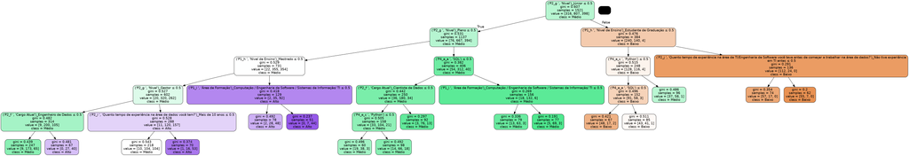

```python
import io
from io import StringIO
from sklearn.tree import export_graphviz
from IPython.display import Image
import graphviz
xvar = df_model.drop(['target',"('P1_b ', 'Genero')"], axis=1)
feature_cols = xvar.columns
dot_data = StringIO()
export_graphviz(ad_model, out_file=dot_data,
                filled=True, rounded=True,
                special_characters=True,feature_names = feature_cols,class_names=['Baixo','Médio','Alto'])
from pydot import graph_from_dot_data
(graph, ) = graph_from_dot_data(dot_data.getvalue())
Image(graph.create_png())
```

```python
#calculando as "feature importance"

feat_importance = ad_model.tree_.compute_feature_importances(normalize=False)
feat_imp_dict = dict(zip(feature_cols, ad_model.feature_importances_))
feat_imp = pd.DataFrame.from_dict(feat_imp_dict, orient='index')
feat_imp.rename(columns = {0:'Importância'}, inplace = True)
feat_imp.sort_values(by=['Importância'], ascending=False).head(10)
```

|  | Importância |
| --- | --- |
| ('P2_g ', 'Nivel')_Júnior | 0.479034 |
| ('P2_g ', 'Nivel')_Pleno | 0.220079 |
| ('P1_h ', 'Nivel de Ensino')_Estudante de Graduação | 0.055558 |
| ('P1_h ', 'Nivel de Ensino')_Mestrado | 0.054368 |
| ('P2_g ', 'Nivel')_Gestor | 0.049218 |
| ('P2_f ', 'Cargo Atual')_Engenheiro de Dados | 0.037356 |
| ('P2_i ', 'Quanto tempo de experiência na área de dados você tem?')_Mais de 10 anos | 0.026349 |
| ('P4_e_c ', 'Python') | 0.026224 |
| ('P4_e_a ', 'SQL') | 0.021670 |
| ('P1_i ', 'Área de Formação')_Computação / Engenharia de Software / Sistemas de Informação/ TI | 0.014755 |

Para avaliar a capacidade preditiva do modelo, são apresentadas as matrizes de confusão na amostra de teste de homens e na base de mulheres:

```python
#obtendo valores preditos
preds_1 = ad_model.predict(X_test)

#obtendo a matriz de confusão
matriz1 = pd.crosstab(index=preds_1,columns=y_test)

# modificando nomes da matriz de confusão para facilitar o entendimento
matriz1.columns.name = "Faixa Real"
matriz1.index.name = "Faixa predita"
matriz1 = matriz1.rename(columns={'0': 'Baixo','1':'Médio','2':'Alto'}, index={'0': 'Baixo','1':'Médio','2':'Alto'})

print("Matriz de confusão na base de teste composta por homens:")
matriz1
```

```
Matriz de confusão na base de teste composta por homens:
```

| Faixa Real Faixa predita | Baixo | Médio | Alto |
| --- | --- | --- | --- |
| Baixo | 45 | 15 | 0 |
| Médio | 46 | 161 | 52 |
| Alto | 3 | 17 | 42 |

```python
#criando base de testes mulheres
df_model2 = df_model_todos[df_model_todos["('P1_b ', 'Genero')"] == "Feminino"]

X_mulher = df_model2.drop(["target","('P1_b ', 'Genero')"], axis=1)
y_mulher = df_model2['target']

#obtendo predições para mulheres
preds_2 = ad_model.predict(X_mulher)

#obtendo a matriz de confusão
matriz2 = pd.crosstab(index=preds_2,columns=y_mulher)


matriz2.columns.name = "Faixa Real"
matriz2.index.name = "Faixa predita"
matriz2 = matriz2.rename(columns={'0': 'Baixo','1':'Médio','2':'Alto'}, index={'0': 'Baixo','1':'Médio','2':'Alto'})

print("Matriz de confusão na base composta por mulheres:")

matriz2
```

```
Matriz de confusão na base composta por mulheres:
```

| Faixa Real Faixa predita | Baixo | Médio | Alto |
| --- | --- | --- | --- |
| Baixo | 65 | 37 | 2 |
| Médio | 42 | 201 | 41 |
| Alto | 0 | 21 | 25 |

```python
acertos = matriz1.loc['Baixo','Baixo'] +  matriz1.loc['Médio','Médio'] + matriz1.loc['Alto','Alto']
total = matriz1.sum().sum()

acuracia = round(acertos*100/total,2)

#import statsmodels
# não consegui identificar o motivo mas o código do intervalo de confiança n rodou dentro do kaggle
#de qualquer forma, deixo o código
#obtendo intervalo de confiança para a acuracia
#ic = statsmodels.stats.proportion.proportion_confint(acertos, total , alpha=0.05, method=  'binom_test')
#print("Acurácia na base de teste de homens:",acuracia, "Intervalo de Confiança(95%): (", round(ic[0]*100,2),";",round(ic[1]*100,2),")" )

print("Acurácia na base de teste de homens:",acuracia)
```

```
Acurácia na base de teste de homens: 65.09
```

```python
matriz2 = pd.crosstab(index=preds_2,columns=y_mulher)
matriz2 = matriz2.rename(columns={'0': 'Baixo','1':'Médio','2':'Alto'}, index={'0': 'Baixo','1':'Médio','2':'Alto'})

# obtendo a quantidade de acertos absolutos
acertos = matriz2.loc['Baixo','Baixo'] +  matriz2.loc['Médio','Médio'] + matriz2.loc['Alto','Alto']
total = matriz2.sum().sum()

acuracia = round(acertos*100/total,2)

#obtendo intervalo de confiança para a acuracia
#ic = statsmodels.stats.proportion.proportion_confint(acertos, total , alpha=0.05, method=  'binom_test')
#print("Acurácia na base de mulheres:",acuracia, "Intervalo de Confiança(95%): (", round(ic[0]*100,2),";",round(ic[1]*100,2),")" )

print("Acurácia na base de mulheres:",acuracia)
```

```
Acurácia na base de mulheres: 67.05
```

Além da acurácia, podemos observar também qual o comportamento dos erros nas duas bases. Podemos ter dois tipos de erro:

- Erro "positivo": Faixa salarial predita é menor do que a real, ou seja, a pessoa está acima do que o padrão sugeriria
- Erro "negativo": Faixa salarial predita é maior do que a real, ou seja, a pessoa está abaixo do que que o padrão sugeriria

```python
# real > predito - a pessoa ganha mais do que a arvore previu

erro_menos_homens = (matriz1.loc['Baixo','Médio'] +  matriz1.loc['Baixo','Alto'] + matriz1.loc['Médio','Alto'])/matriz1.sum().sum()
erro_menos_mulheres =(matriz2.loc['Baixo','Médio'] +  matriz2.loc['Baixo','Alto'] + matriz2.loc['Médio','Alto'])/matriz2.sum().sum()

print("Erro positivo para homens:",round(erro_menos_homens*100,2),"% e para mulheres:",round(erro_menos_mulheres*100,2),"%")

# real < predito - a pessoa ganha menos do que a arvore previu

erro_menos_homens = (matriz1.loc['Médio','Baixo'] +  matriz1.loc['Alto','Baixo'] + matriz1.loc['Alto','Médio'])/matriz1.sum().sum()
erro_menos_mulheres =(matriz2.loc['Médio','Baixo'] +  matriz2.loc['Alto','Baixo'] + matriz2.loc['Alto','Médio'])/matriz2.sum().sum()

print("Erro negativo para homens:",round(erro_menos_homens*100,2),"% e para mulheres:",round(erro_menos_mulheres*100,2),"%")
```

```
Erro positivo para homens: 17.59 % e para mulheres: 18.43 %
Erro negativo para homens: 17.32 % e para mulheres: 14.52 %
```

Mesmo que os resultados acima sejam otimistas, vemos que os fatores mais importantes na predição de salário são a senioridade do cargo, tempo de experiência e ocupar cargos relacionados à engenharia. Na análise exploratória, vimos que esses são pontos de difícil acesso para as mulheres. Podemos inferir, então, que a disparidade salarial se deve à dificuldade que as mulheres tem de acessarem cargos mais altos, formações/ocupações ligadas à computação ou terem tempo de experiência equivalente.

Sendo assim, podemos falar em uma última métafora da desigualdade: **a metáfora do teto de vidro**, que é definida pela dificuldade de mulheres alcançarem cargos mais altos, apesar de não existirem barreiras visíveis (objetivas) que as impeçam.

## Conclusão

- O cenário pode ser considerado positivo, visto que em condições de igualdade é provavável que haja equivalência salarial.
- A análise exploratória indica que **ainda não estamos em codições de igualdade**, por isso é necessário:
  > - Criar ambientes agradáveis que permitam a permanência das mulheres
  > - Criar ações propositivas para que elas alcancem cargos de maior senioridade
  > - Manter e intensificar as ações afirmativas de atração de mulheres para a área de dados e de meninas para cursos de graduação ligados a dados.